# Crime trends in London and other global cities

Dr Matt Ashby, UCL Centre for Global City Policing

These slides: **lesscrime.info/slides/gcb-siu-2025**

# Comparing crime across cities is difficult

## Problem 1: Crime definitions vary

> A person smashes the window on a parked car and removes money from the glove box, intending to spend the money on drugs and without the permission of the vehicle owner.

**London**  
theft from motor vehicle

**Los Angeles**  
burglary of auto

## Problem 2: Different cities publish statistics in different ways

Some cities publish incident-level data …

| date_time | type | address |
| --- | --- | --- |
| 2025-11-23 23:31 | res. burglary | 13 High Road … |
| 2025-11-24 07:15 | res. burglary | Flat A, 6 Gr … |
| 2025-11-24 09:39 | attmpt. res. burglary | 780 Plane St … |
| 2025-11-24 10:54 | res. burglary | McDonalds, 1 … |

… others publish crime counts

| month | category | count |
| --- | --- | --- |
| 2025 Jan | homicide | 2 |
| 2025 Feb | homicide | 4 |
| 2025 Mar | homicide | 3 |
| 2025 Apr | homicide | 3 |

## Solution: harmonise categories to follow England & Wales recording rules

**e.g. residential burglary**

Barcelona:

- *robos con fuerza en viviendas* (robbery with force in homes)

Los Angeles:

- burglary and attempted burglary in any of residences, hotels, motels, halls of residence, mobile homes, care homes, foster homes or homeless shelters

New York:

- burglary, residence, day
- burglary, residence, night
- burglary, residence, unknown time
- burglary, unclassified occurring in a residence.

## Problem 3: City boundaries affect crime rates

‘Small’ London

**364** personal robberies  
per 100,000 residents

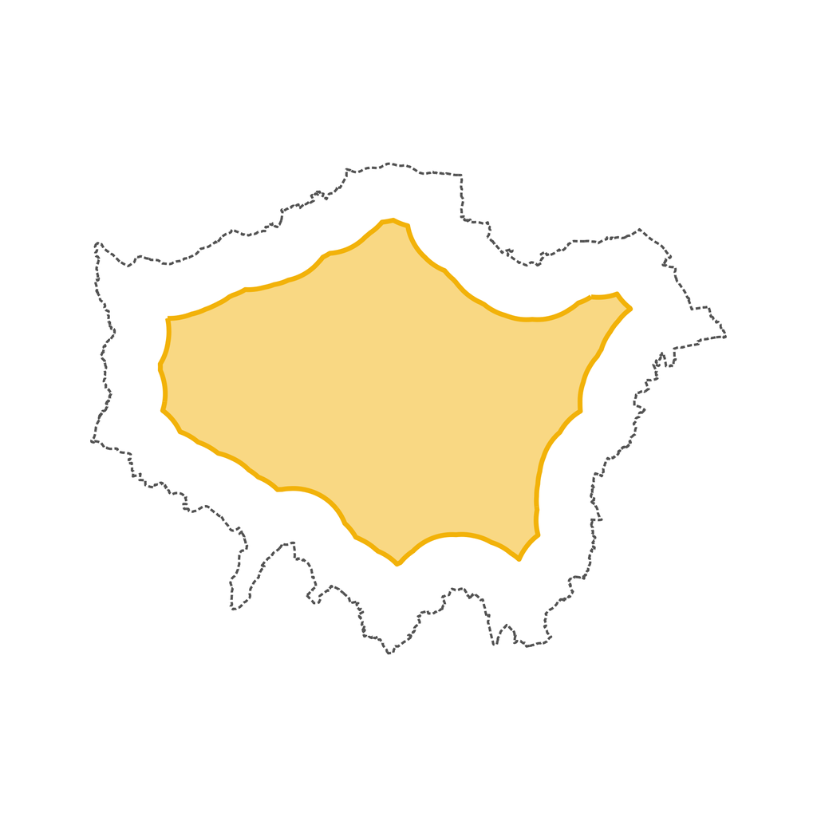

8% *higher* than Paris

Actual London

**305** personal robberies  
per 100,000 residents

[figure not shown]

9% *lower* than Paris

‘Big’ London

**279** personal robberies  
per 100,000 residents

[figure not shown]

17% *lower* than Paris

## Solution: construct a ‘version’ of each city that matches London

**London**  
admin boundary matches urban area fairly well

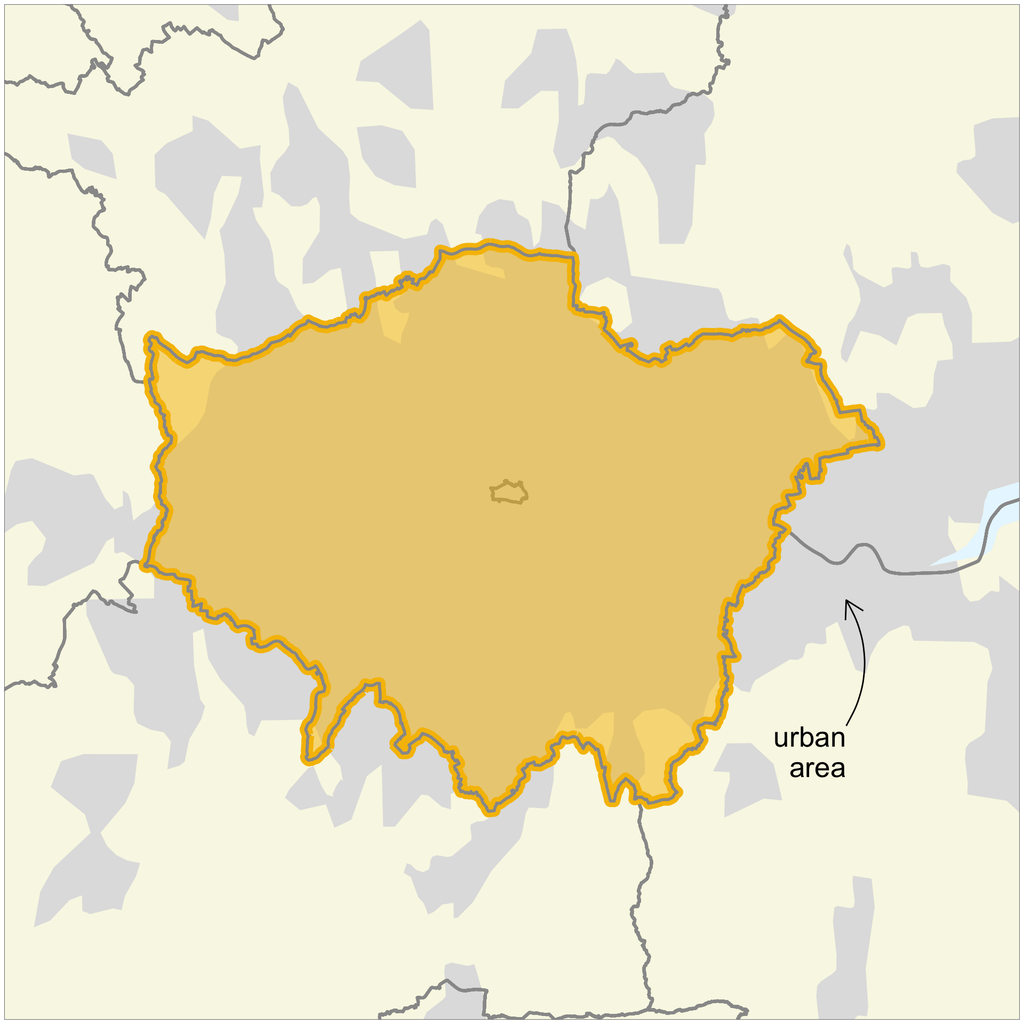

**Paris**  
admin boundary much smaller than urban area

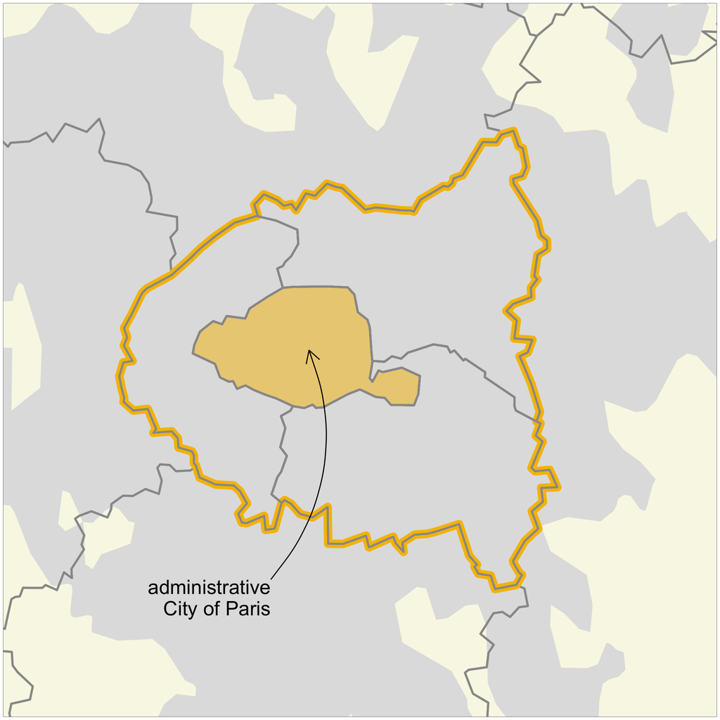

## Solution: construct a ‘version’ of each city that matches London

**London**  
admin boundary matches urban area fairly well

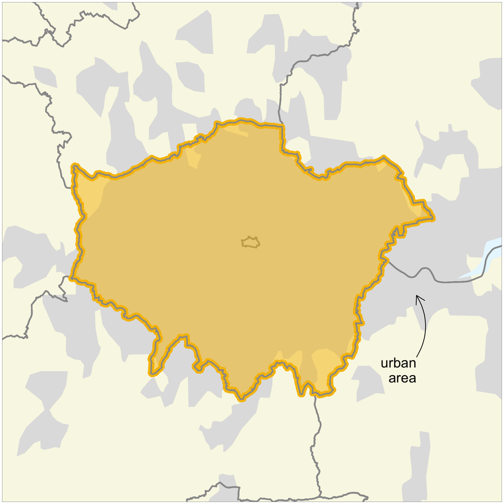

**Paris**  
admin boundary much smaller than urban area

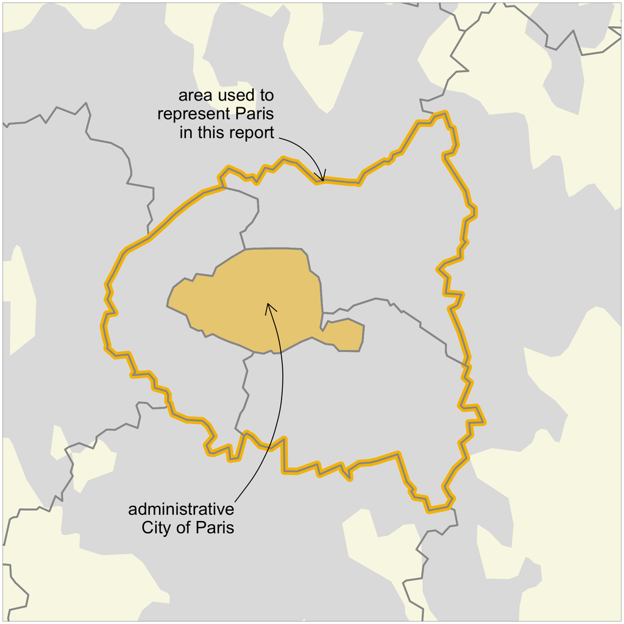

# How crime rates in London compare to other global cities

## Focus on highly developed countries

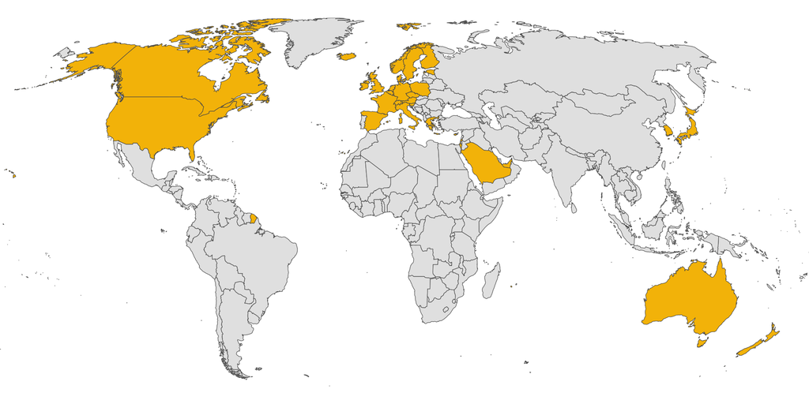

UN Human Development Index >0.90

## Focus on global cities in highly developed countries

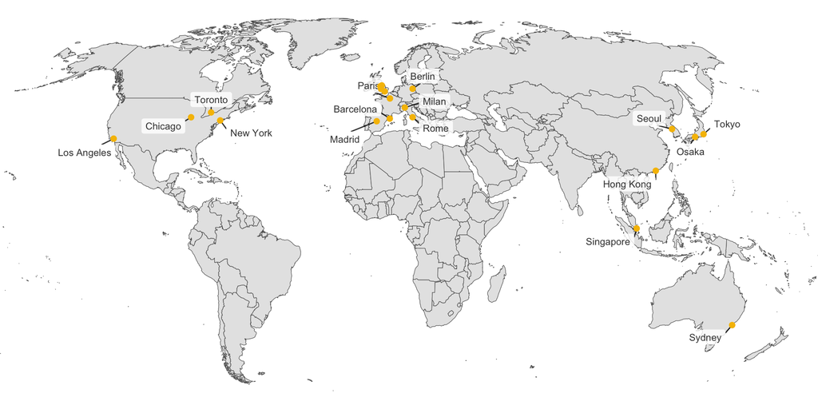

Cities with 2.5 million people (5.0 million in Asia)

## Homicide: long-term trend in London

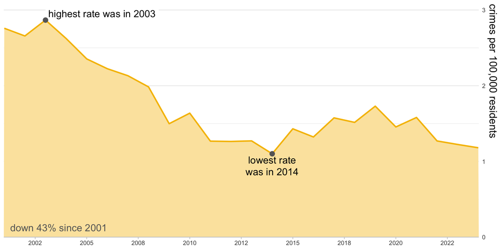

## Homicide: global cities

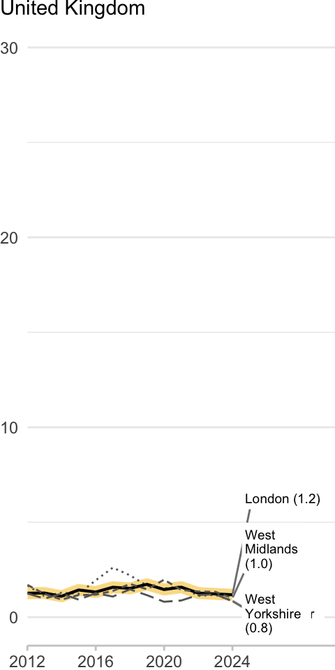

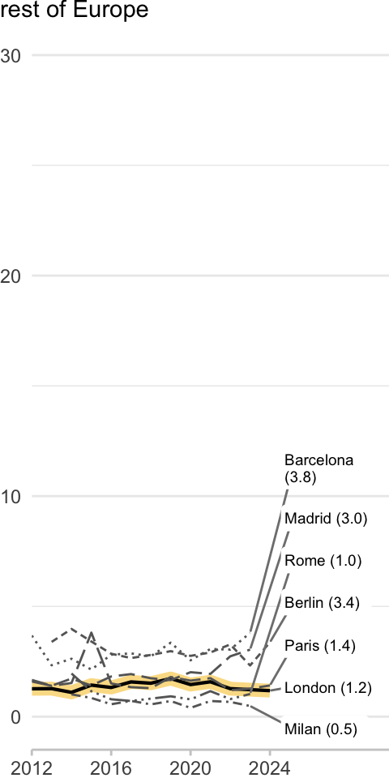

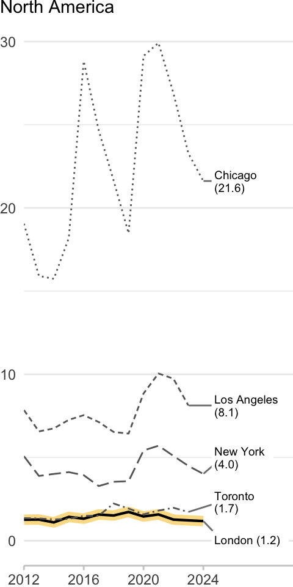

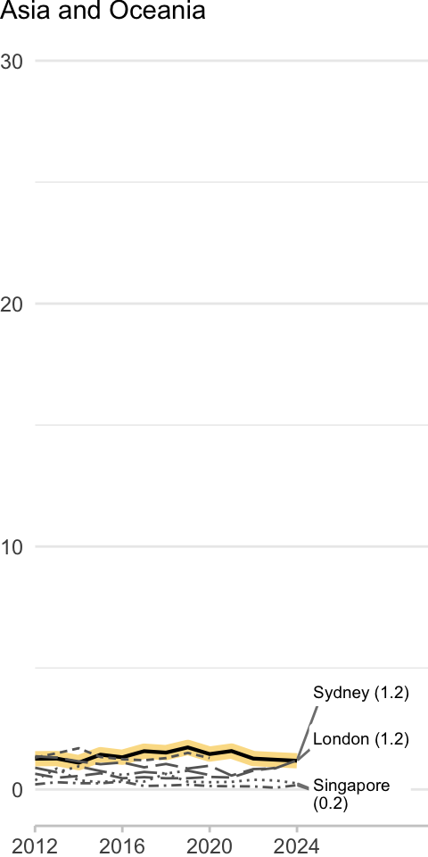

All rates are per 100,000 residents

## Homicide: global cities

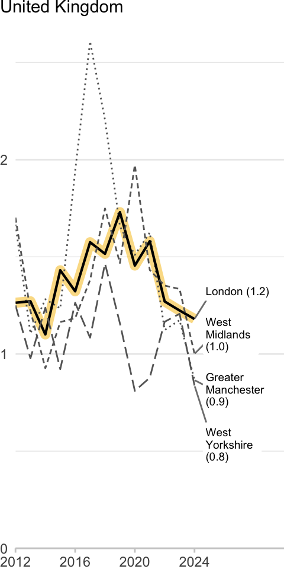

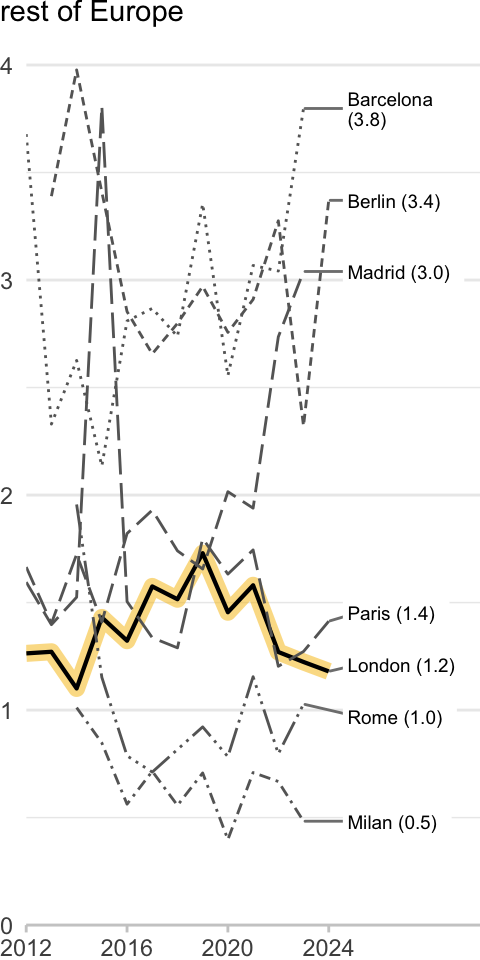

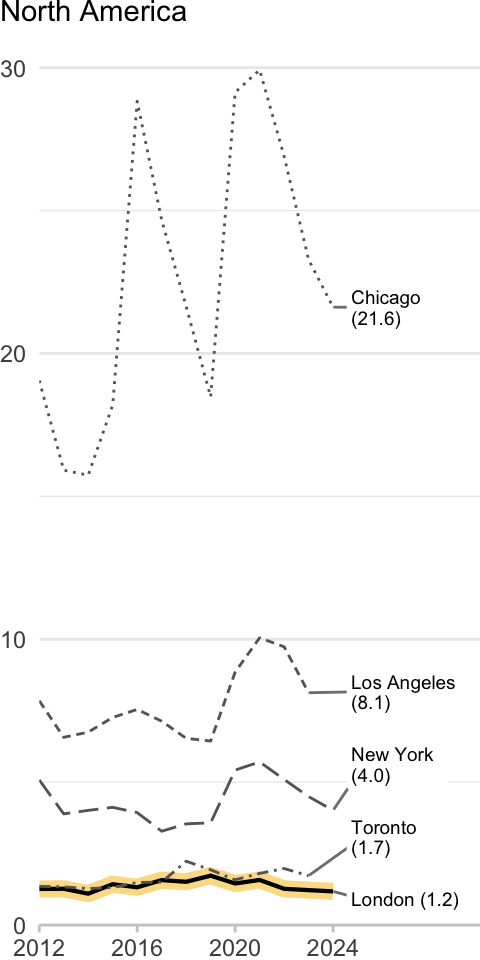

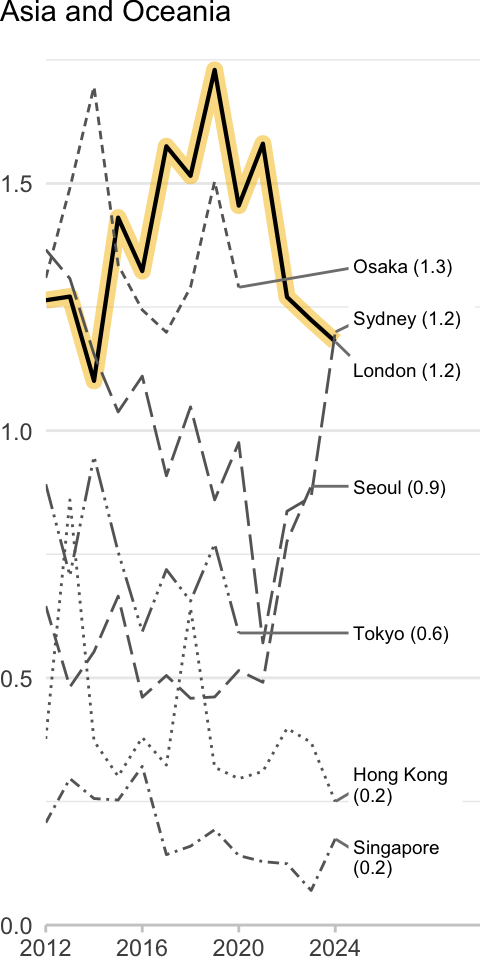

All rates are per 100,000 residents

## Assault with injury: long-term trend in London

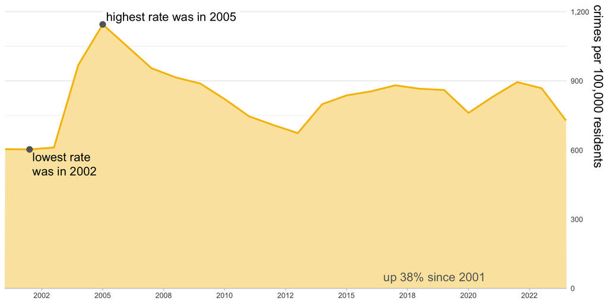

## Assault with injury: global cities

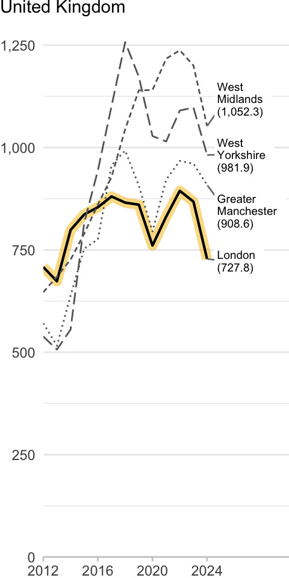

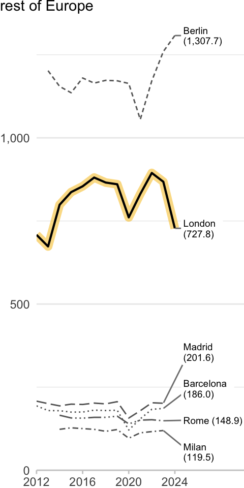

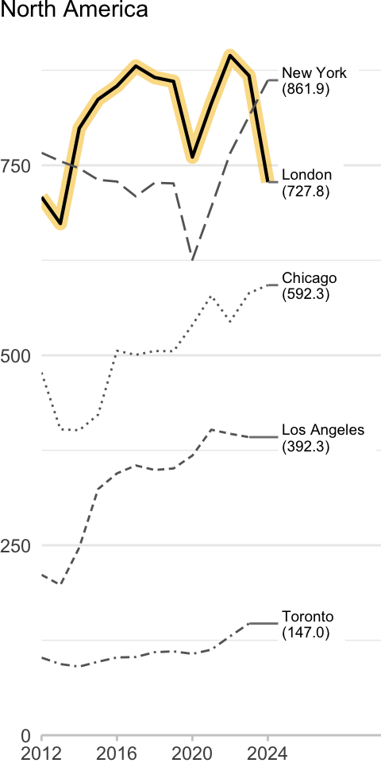

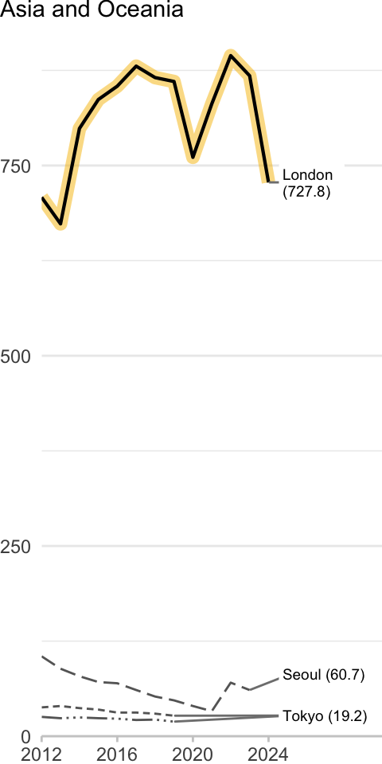

All rates are per 100,000 residents

## Rape: long-term trend in London

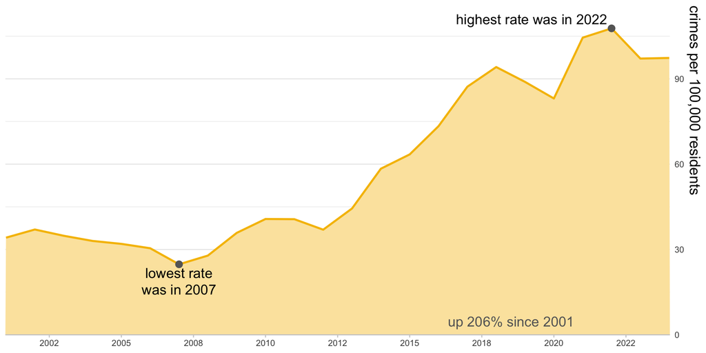

## Rape: global cities

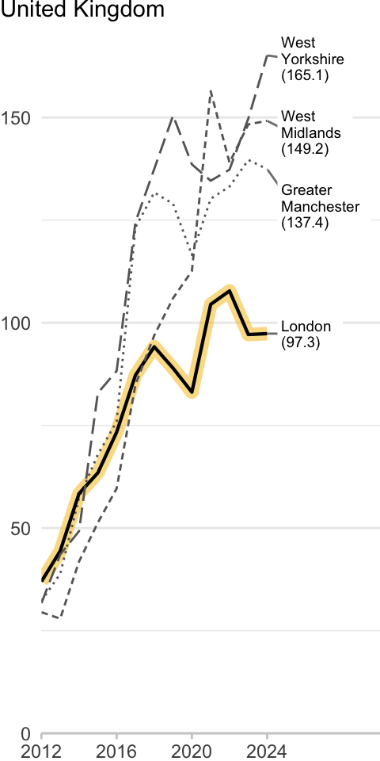

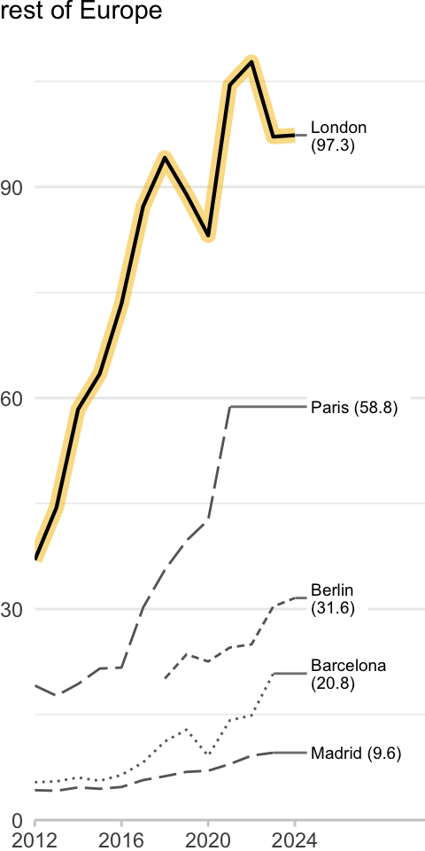

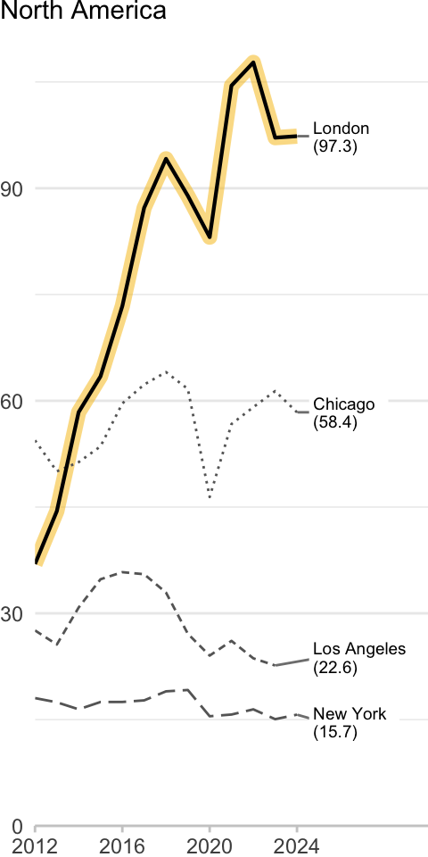

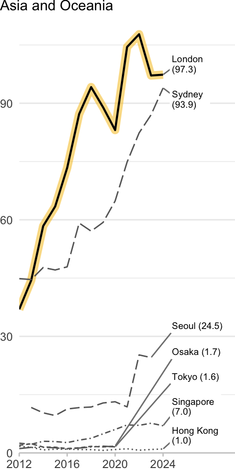

All rates are per 100,000 residents

## Personal robbery: long-term trend in London

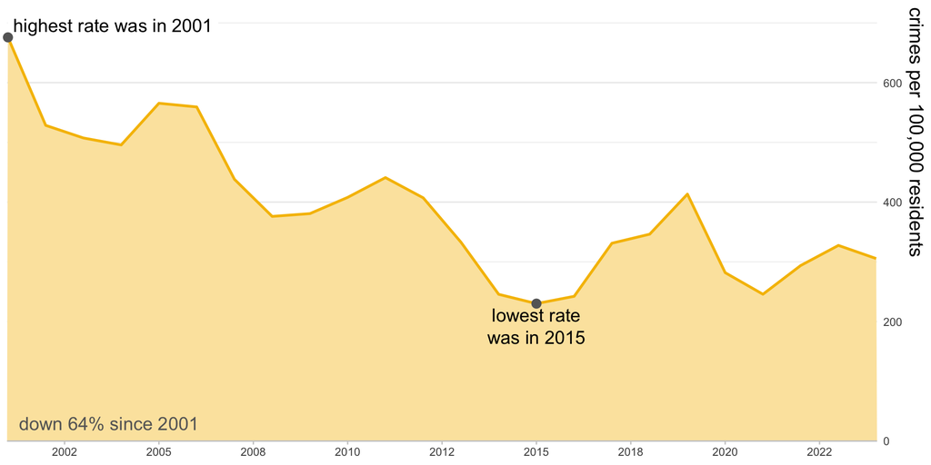